# Phân tích Dữ liệu Khám phá (EDA) - Chất lượng Rượu vang Đỏ

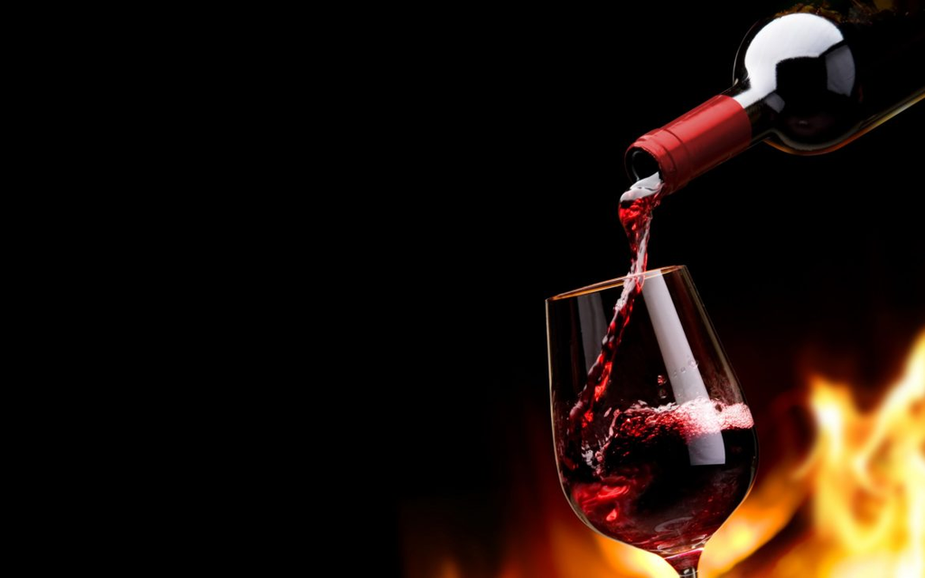

**Quy trình**:

- Thống kê Mô tả Sơ bộ
- Làm sạch Dữ liệu
- Trực quan hóa Dữ liệu
- Tổng kết

### Bài làm

#### 1.Import thư viện

```python
#Thư viện xử lý dữ liệu
import numpy as np
import pandas as pd
#Thư viện trực quan hóa dữ liệu
import seaborn as sns
import matplotlib.pyplot as plt
sns.set(style='whitegrid',palette='muted',font_scale=1.2)
%matplotlib inline
```

#### 2.Đọc - Kiểm tra dữ liệu

```python
df=pd.read_csv('winequality-red.csv')
print("Dữ liệu 5 dòng đầu tiên :")
df.head()
```

```
Dữ liệu 5 dòng đầu tiên :
```

|  | fixed acidity | volatile acidity | citric acid | residual sugar | chlorides | free sulfur dioxide | total sulfur dioxide | density | pH | sulphates | alcohol | quality |
| --- | --- | --- | --- | --- | --- | --- | --- | --- | --- | --- | --- | --- |
| 0 | 7.4 | 0.70 | 0.00 | 1.9 | 0.076 | 11.0 | 34.0 | 0.9978 | 3.51 | 0.56 | 9.4 | 5 |
| 1 | 7.8 | 0.88 | 0.00 | 2.6 | 0.098 | 25.0 | 67.0 | 0.9968 | 3.20 | 0.68 | 9.8 | 5 |
| 2 | 7.8 | 0.76 | 0.04 | 2.3 | 0.092 | 15.0 | 54.0 | 0.9970 | 3.26 | 0.65 | 9.8 | 5 |
| 3 | 11.2 | 0.28 | 0.56 | 1.9 | 0.075 | 17.0 | 60.0 | 0.9980 | 3.16 | 0.58 | 9.8 | 6 |
| 4 | 7.4 | 0.70 | 0.00 | 1.9 | 0.076 | 11.0 | 34.0 | 0.9978 | 3.51 | 0.56 | 9.4 | 5 |

```python
print("\nThông tin tổng quan về dữ liệu:")
df.info()
```

```
Thông tin tổng quan về dữ liệu:
<class 'pandas.core.frame.DataFrame'>
RangeIndex: 1599 entries, 0 to 1598
Data columns (total 12 columns):
 #   Column                Non-Null Count  Dtype
---  ------                --------------  -----
 0   fixed acidity         1599 non-null   float64
 1   volatile acidity      1599 non-null   float64
 2   citric acid           1599 non-null   float64
 3   residual sugar        1599 non-null   float64
 4   chlorides             1599 non-null   float64
 5   free sulfur dioxide   1599 non-null   float64
 6   total sulfur dioxide  1599 non-null   float64
 7   density               1599 non-null   float64
 8   pH                    1599 non-null   float64
 9   sulphates             1599 non-null   float64
 10  alcohol               1599 non-null   float64
 11  quality               1599 non-null   int64
dtypes: float64(11), int64(1)
memory usage: 150.0 KB
```

**Nhận xét** :  
Tập dữ liệu gốc có 1599 mẫu và 12 cột  
Tất cả dữ liệu đều là kiểu số không có giá trị nào bị thiếu Các thuộc tính trong dữ liệu gồm :

- `fixed acidity` : Nồng độ acid cố định
- `volatile acidity` : Nồng độ acid dễ bay hơi
- `citric acid` : Lượng acid citric
- `residual sugar`: Lượng đường tồn dư
- `chlorides`: Muối Cl- trong rượu
- `free sulfur dioxid`e: Lượng SO2 tự do ( chất bảo quản )
- `total sulfur dioxide` : Tổng SO2 gồm gốc tự do và liên kết
- `density`: Tỉ trong của rượu
- `pH`
- `sulphates`
- `alcohol`: Nồng độ cồn
- `quality` : Chất lượng

#### 3. Thống kê dữ liệu

```python
df.describe()
```

|  | fixed acidity | volatile acidity | citric acid | residual sugar | chlorides | free sulfur dioxide | total sulfur dioxide | density | pH | sulphates | alcohol | quality |
| --- | --- | --- | --- | --- | --- | --- | --- | --- | --- | --- | --- | --- |
| count | 1599.000000 | 1599.000000 | 1599.000000 | 1599.000000 | 1599.000000 | 1599.000000 | 1599.000000 | 1599.000000 | 1599.000000 | 1599.000000 | 1599.000000 | 1599.000000 |
| mean | 8.319637 | 0.527821 | 0.270976 | 2.538806 | 0.087467 | 15.874922 | 46.467792 | 0.996747 | 3.311113 | 0.658149 | 10.422983 | 5.636023 |
| std | 1.741096 | 0.179060 | 0.194801 | 1.409928 | 0.047065 | 10.460157 | 32.895324 | 0.001887 | 0.154386 | 0.169507 | 1.065668 | 0.807569 |
| min | 4.600000 | 0.120000 | 0.000000 | 0.900000 | 0.012000 | 1.000000 | 6.000000 | 0.990070 | 2.740000 | 0.330000 | 8.400000 | 3.000000 |
| 25% | 7.100000 | 0.390000 | 0.090000 | 1.900000 | 0.070000 | 7.000000 | 22.000000 | 0.995600 | 3.210000 | 0.550000 | 9.500000 | 5.000000 |
| 50% | 7.900000 | 0.520000 | 0.260000 | 2.200000 | 0.079000 | 14.000000 | 38.000000 | 0.996750 | 3.310000 | 0.620000 | 10.200000 | 6.000000 |
| 75% | 9.200000 | 0.640000 | 0.420000 | 2.600000 | 0.090000 | 21.000000 | 62.000000 | 0.997835 | 3.400000 | 0.730000 | 11.100000 | 6.000000 |
| max | 15.900000 | 1.580000 | 1.000000 | 15.500000 | 0.611000 | 72.000000 | 289.000000 | 1.003690 | 4.010000 | 2.000000 | 14.900000 | 8.000000 |

**Nhận xét** :  
`Count` (Số lượng) tất cả đều đủ 1599 mẫu  
`Mean`(Trung bình) & `std` (độ lệch chuẩn) của **`total sulfur dioxide`** rất cao  
`Min` `Max` `Phân vị` :

- **residual sugar** **chloride** **total sulfur dioxide** có giá trị `max` cao hơn nhiều lần so với phân vị Q3 (75%) => Phân phối lệch

#### 4.Làm sạch dữ liệu

##### a) Kiểm tra dữ liệu trùng lặp

```python
duplicate_rows=df.duplicated().sum()
print(f"Số lượng hàng bị trùng lặp: {duplicate_rows}")
```

```
Số lượng hàng bị trùng lặp: 240
```

##### b) Làm sạch dữ liệu trùng lặp

```python
#Tạo dataframe lưu dữ liệu đã xóa các hàng trùng lặp
df_cleaned=df.drop_duplicates()
#Kiểm tra lại dữ liệu sau khi xóa
print("Kích thước dữ liệu gốc:", df.shape)
print("Kích thước dữ liệu sau khi làm sạch:", df_cleaned.shape)
print(f"Đã loại bỏ {df.shape[0] - df_cleaned.shape[0]} hàng trùng lặp.")
#Reset index của dataframe đã làm sạch
df_cleaned.reset_index(drop=True, inplace=True)
```

```
Kích thước dữ liệu gốc: (1599, 12)
Kích thước dữ liệu sau khi làm sạch: (1359, 12)
Đã loại bỏ 240 hàng trùng lặp.
```

#### 5.Trực quan hóa dữ liệu

##### a) Phân tích đơn biến

Phân phối của biến `quality`

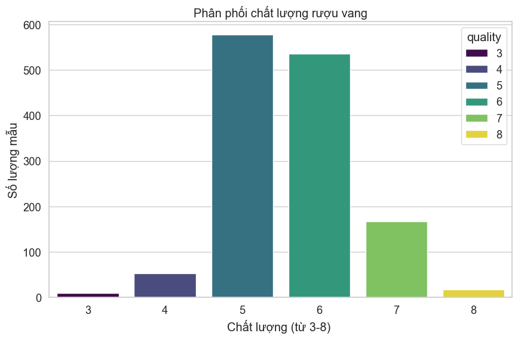

```python
plt.figure(figsize=(10,6))
sns.countplot(x='quality',data=df_cleaned,palette='viridis',hue='quality',order=sorted(df_cleaned['quality'].unique()))
plt.title("Phân phối chất lượng rượu vang")
plt.xlabel("Chất lượng (từ 3-8) ")
plt.ylabel("Số lượng mẫu")
plt.show()
```

**Nhận xét** :  
+ Phân phối chất lượng rượu không thay đổi nhiều khi loại bỏ hàng trùng lặp. Phần lớn vẫn có chất lượng ở **mức 5 và 6**  
+ Vẫn có thể tồn tại **Dữ liệu mất cân bằng**

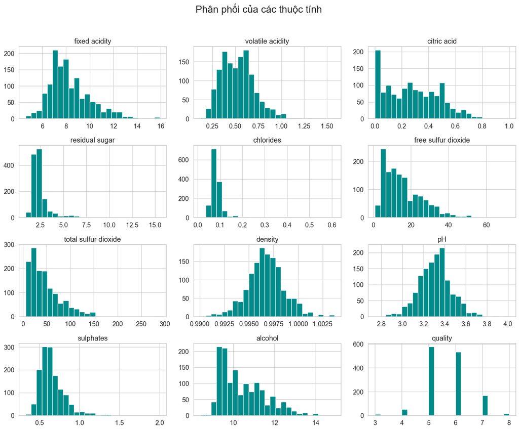

```python
# Vẽ histogram
df_cleaned.hist(figsize=(15,12),bins=25,color='darkcyan')
plt.suptitle('Phân phối của các thuộc tính ',y=1.02,size=20)
plt.tight_layout()
plt.show()
```

**Nhận xét** :  
+ Phân phối lệch phải : `volatile acidity`, `residual sugar`, `chlorides`, `free sulfur dioxide`, `total sulfur dioxide`, `sulphates, alcohol`  
+ Phân phối gần giống phân phối chuẩn : `destiny`,`pH`

##### b) Phân tích đa biến

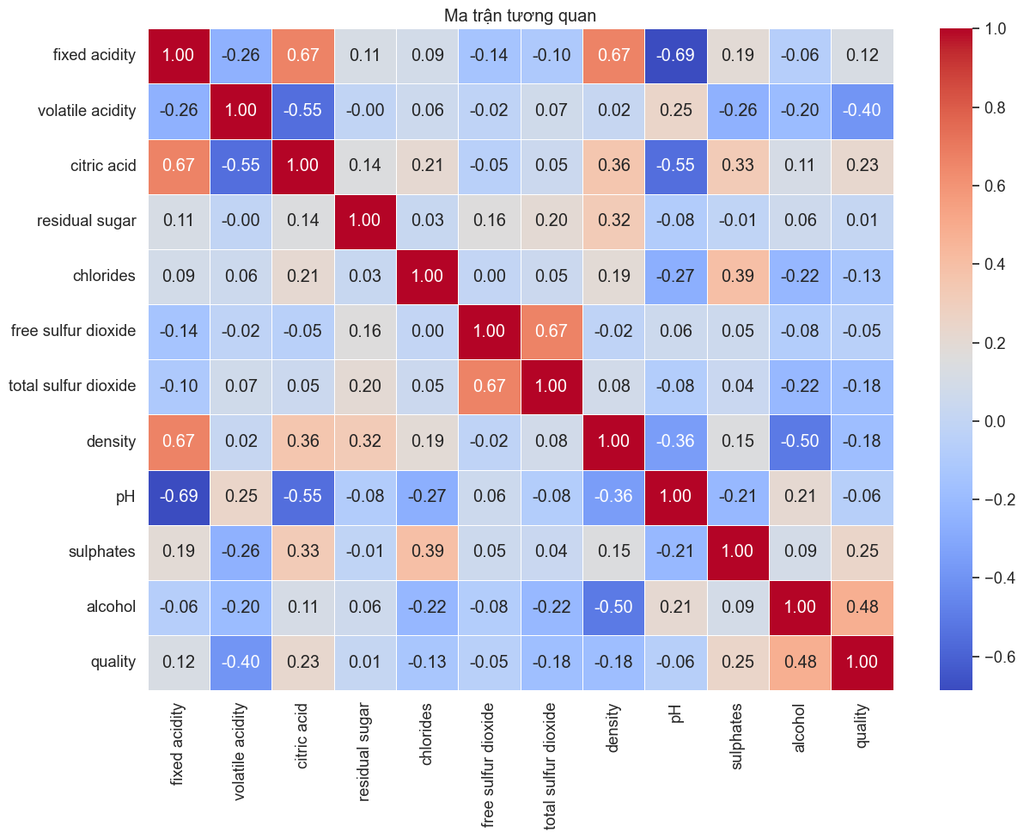

```python
#Ma trận tương quan
plt.figure(figsize=(14,10))
corr=df_cleaned.corr()
sns.heatmap(corr,annot=True,cmap='coolwarm',linewidths=0.5,fmt='.2f')
plt.title('Ma trận tương quan')
plt.show()
```

**Nhận xét** :  
+ `alcohol` có mối tương quan lớn với `quality`  
+ `volatile acidity` có tương quan âm mạnh nhất

##### c) Mối quan hệ giữa từng thuộc tính

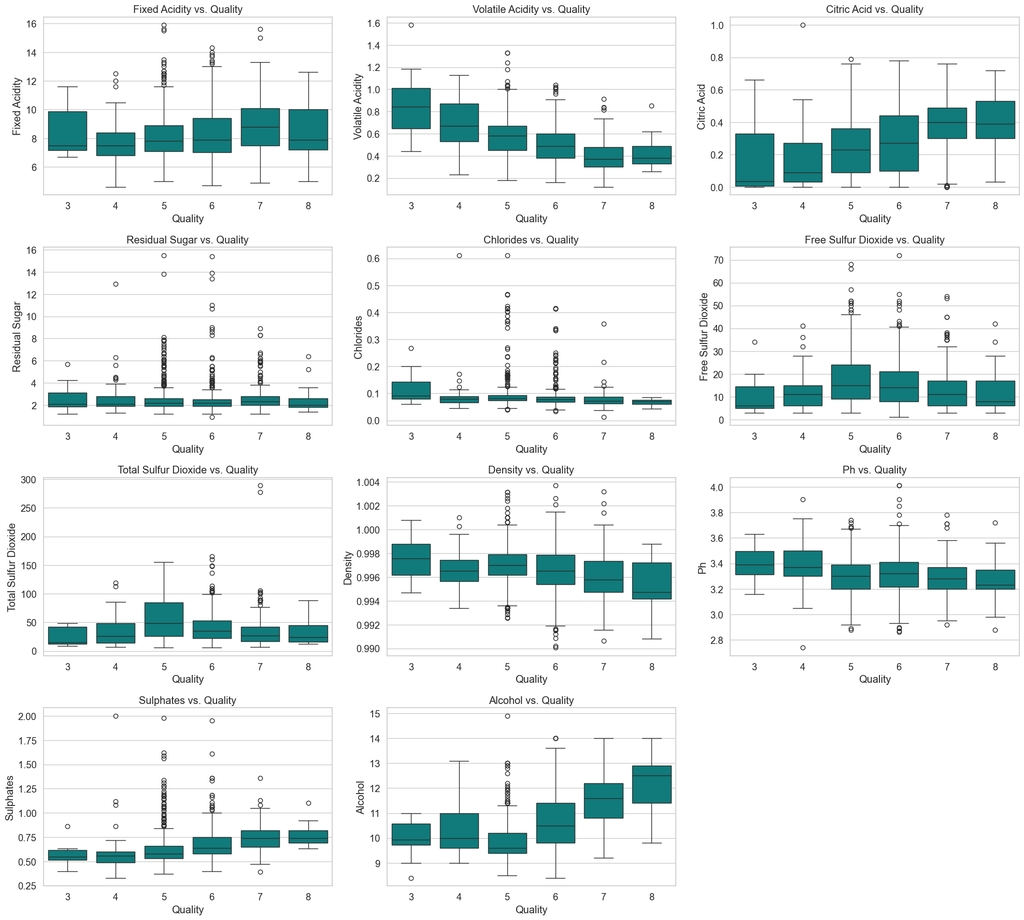

```python
fig, axes = plt.subplots(4, 3, figsize=(20, 18))
axes = axes.flatten()
feature_cols = [col for col in df_cleaned.columns if col != 'quality']
for i, col in enumerate(feature_cols):
    sns.boxplot(x='quality', y=col, data=df_cleaned, ax=axes[i], color='darkcyan')  # dùng color
    axes[i].set_title(f'{col.replace("_"," ").title()} vs. Quality')
    axes[i].set_xlabel('Quality')
    axes[i].set_ylabel(col.replace("_", " ").title())
# Ẩn subplot thừa
if len(feature_cols) < len(axes):
    for j in range(len(feature_cols), len(axes)):
        axes[j].set_visible(False)
plt.tight_layout()
plt.show()
```

**Nhận xét** :  
+ Xu hướng rõ ràng : `alcohol`tăng theo chất lượng rượu và `volatile acidity` càng cao thì chất lượng càng giảm  
+ Xu hướng yếu hơn : `sulphats`,`citric acid` có xu hướng tăng nhẹ  
**CÁC THUỘC TÍNH CÒN LẠI KHÔNG CÓ XU HƯỚNG RÕ RÀNG**

#### 6. Tổng Kết

- **Chất lượng Dữ liệu**: Dữ liệu ban đầu không có giá trị thiếu nhưng chứa 240 hàng trùng lặp, đã được loại bỏ thành công.
- **Yếu tố Ảnh hưởng đến Chất lượng**: Phân tích trên dữ liệu sạch xác nhận rằng alcohol và volatile acidity là hai chỉ số quan trọng nhất để dự đoán chất lượng rượu vang đỏ.